# Preprocess

```python
import pandas as pd
import  warnings
import numpy as np

warnings.filterwarnings('ignore')
```

### Read the excel file

```python
df = pd.read_excel('data/Delivery_truck_trip_data.xlsx')
```

```python
df.head()
```

|  | GpsProvider | BookingID | Market/Regular | BookingID_Date | vehicle_no | Origin_Location | Destination_Location | Org_lat_lon | Des_lat_lon | Data_Ping_time | ... | TRANSPORTATION_DISTANCE_IN_KM | vehicleType | Minimum_kms_to_be_covered_in_a_day | Driver_Name | Driver_MobileNo | customerID | customerNameCode | supplierID | supplierNameCode | Material Shipped |
| --- | --- | --- | --- | --- | --- | --- | --- | --- | --- | --- | --- | --- | --- | --- | --- | --- | --- | --- | --- | --- | --- |
| 0 | CONSENT TRACK | MVCV0000927/082021 | Market | 2020-08-17 14:59:01.000 | KA590408 | TVSLSL-PUZHAL-HUB,CHENNAI,TAMIL NADU | ASHOK LEYLAND PLANT 1- HOSUR,HOSUR,KARNATAKA | 13.1550,80.1960 | 12.7400,77.8200 | 2020-08-24 00:05:09 | ... | 320.0 | NaN | NaN | NaN | NaN | ALLEXCHE45 | Ashok leyland limited | VIJEXHOSR7 | VIJAY TRANSPORT | BRACKET / GRAB HANDLE |
| 1 | VAMOSYS | VCV00014271/082021 | Regular | 2020-08-27 16:22:22.827 | TN30BC5917 | DAIMLER INDIA COMMERCIAL VEHICLES,KANCHIPURAM,... | DAIMLER INDIA COMMERCIAL VEHICLES,KANCHIPURAM,... | 12.8390,79.9540 | 12.8390,79.9540 | 2020-08-28 12:40:28 | ... | 103.0 | NaN | NaN | RAMESH | NaN | DMREXCHEUX | Daimler india commercial vehicles pvt lt | VJLEXSHE09 | VJ LOGISTICS | ZB MODEL PLATE / 3143 |
| 2 | CONSENT TRACK | VCV00014382/082021 | Regular | 2020-08-27 17:59:24.987 | TN22AR2748 | LUCAS TVS LTD-PONDY,PONDY,PONDICHERRY | LUCAS TVS LTD-PONDY,PONDY,PONDICHERRY | 11.8710,79.7390 | 11.8710,79.7390 | 2020-08-28 09:05:09 | ... | 300.0 | NaN | NaN | GIRI | NaN | LUTGCCHE06 | Lucas tvs ltd | GSTEXLAK1Q | G.S. TRANSPORT | LETTERING / FUSO |
| 3 | VAMOSYS | VCV00014743/082021 | Regular | 2020-08-28 00:48:24.503 | TN28AQ0781 | DAIMLER INDIA COMMERCIAL VEHICLES,KANCHIPURAM,... | DAIMLER INDIA COMMERCIAL VEHICLES,KANCHIPURAM,... | 12.8390,79.9540 | 12.8390,79.9540 | 2020-08-28 12:40:31 | ... | 61.0 | NaN | NaN | RAVI | NaN | DMREXCHEUX | Daimler india commercial vehicles pvt lt | ARVEXNAM09 | ARVINTH TRANSPORT | LU STRUT RA / RADIUS ROD |
| 4 | VAMOSYS | VCV00014744/082021 | Regular | 2020-08-28 01:23:19.243 | TN68F1722 | LUCAS TVS LTD-PONDY,PONDY,PONDICHERRY | LUCAS TVS LTD-PONDY,PONDY,PONDICHERRY | 11.8720,79.6320 | 11.8720,79.6320 | 2020-08-28 12:40:29 | ... | 240.0 | NaN | NaN | TAMIL | NaN | LUTGCCHE06 | Lucas tvs ltd | SRTEXKOR96 | SR TRANSPORTS | WISHBONE / V ROD/HDT |

5 rows × 32 columns

```python
from facets_overview.generic_feature_statistics_generator import GenericFeatureStatisticsGenerator
proto = GenericFeatureStatisticsGenerator().ProtoFromDataFrames([{'name': 'test', 'table': df}])
```

```python
from IPython.core.display import display, HTML
import base64
protostr = base64.b64encode(proto.SerializeToString()).decode("utf-8")
HTML_TEMPLATE = """
        <script src="https://cdnjs.cloudflare.com/ajax/libs/webcomponentsjs/1.3.3/webcomponents-lite.js"></script>
        <link rel="import" href="/nbextensions/facets-dist/facets-jupyter.html" >
        <facets-overview id="elem"></facets-overview>
        <script>
          document.querySelector("#elem").protoInput = "{protostr}";
        </script>"""
html = HTML_TEMPLATE.format(protostr=protostr)
display(HTML(html))
```

### Numbers of anomalies

```python
df.ontime.value_counts(dropna=False)
```

```
ontime
NaN    4332
G      2548
Name: count, dtype: int64
```

```python
df.delay.value_counts(dropna=False)
```

```
delay
R      4342
NaN    2538
Name: count, dtype: int64
```

Rows where the value of 'ontime' and the value of 'delay' conflicts are erroneous information. Remove them.

```python
df = df[((df['ontime'] == 'G') & (df['delay'].isna())) | ((df['ontime'].isna()) & (df['delay'] == 'R'))]
df.shape
```

```
(6842, 32)
```

```python
df.ontime.value_counts(dropna=False)
```

```
ontime
NaN    4318
G      2524
Name: count, dtype: int64
```

```python
df.delay.value_counts(dropna=False)
```

```
delay
R      4318
NaN    2524
Name: count, dtype: int64
```

```python
df.loc[df["ontime"] == "G", "ontime"] = 0
df.loc[df["ontime"].isna(), "ontime"] = 1
df.drop('delay', axis=1, inplace= True)
```

63% (4318/6842) of the orders are delayed (anomalies).

```python
df.rename(columns={"Market/Regular ": "Market/Regular"}, inplace=True)
df['Market/Regular'].value_counts(dropna=False)
```

```
Market/Regular
Regular    6773
Market       69
Name: count, dtype: int64
```

### Drop duplicate/redundant columns

```python
df[df['Destination_Location'] != df['DestinationLocation']]
df.drop('DestinationLocation', axis=1, inplace= True)
```

Drop rows about driver information, because 50% of the records don't have driver information. Even for those who have, there can be drivers with the same name.

```python
df.drop(["Driver_Name", "Driver_MobileNo"], axis=1, inplace=True)
```

### Drop names of locations and keep codes of locations

```python
df.drop(["Origin_Location", "Destination_Location", "Current_Location"], axis=1, inplace=True)
```

### Replace vehicleType, OriginLocation_Code, DestinationLocation_Code value NaN with a categorical value

```python
df.loc[df["vehicleType"].isna(), "vehicleType"] = 'vehicleType'
df.loc[df["OriginLocation_Code"].isna(), "OriginLocation_Code"] = 'OriginLocation_Code'
df.loc[df["DestinationLocation_Code"].isna(), "DestinationLocation_Code"] = 'DestinationLocation_Code'
```

### Drop name codes of customers/suppliers and keep ID of customers/suppliers

```python
df.drop(["customerNameCode", "supplierNameCode"], axis=1, inplace=True)
```

If Minimum_kms_to_be_covered_in_a_day is required, it's either 250 or 275. If Minimum_kms_to_be_covered_in_a_day is required, replace it with 250. If not, replace it with 0.

```python
df.loc[df["Minimum_kms_to_be_covered_in_a_day"].isna(), "Minimum_kms_to_be_covered_in_a_day"] = 0
df.loc[df["Minimum_kms_to_be_covered_in_a_day"] > 0, "Minimum_kms_to_be_covered_in_a_day"] = 250
df['Minimum_kms_to_be_covered_in_a_day'].value_counts(dropna=False)
```

```
Minimum_kms_to_be_covered_in_a_day
0.0      4054
250.0    2788
Name: count, dtype: int64
```

Because 'trip_end_date' "cant be considered for calculating delay", drop it.

```python
df.drop('trip_end_date', axis=1, inplace=True)
```

### Drop BookingID and BookingID_Date and keep trip start date, because transportation is the focus.

```python
df.BookingID.value_counts(dropna=False)
```

```
BookingID
MVCV0000798/082021    3
VCV00014072/082021    2
MVCV0000759/082021    2
AEIBK1902026          2
MVCV0000927/082021    1
                     ..
AEIBK2022189          1
AEIBK2023141          1
AEIBK2022871          1
AEIBK2022931          1
WDSBKTP42858          1
Name: count, Length: 6837, dtype: int64
```

```python
df.drop(['BookingID', 'BookingID_Date'], axis=1, inplace=True)
```

### In the model, current location and gps information is irrelevant

```python
df.drop(['Curr_lat', 'Curr_lon'], axis=1, inplace=True)
df.drop(['GpsProvider', 'Data_Ping_time'], axis=1, inplace=True)
```

### Actual ETA can also be dropped, we only need planned ETA and 'ontime'.

```python
df.drop(['actual_eta'], axis=1, inplace=True)
```

### Break lat_lons into latitudes and longitudes

```python
df[['Org_lat', 'Org_lon']] = df.Org_lat_lon.str.split(',', expand=True)
df[['Des_lat', 'Des_lon']] = df.Des_lat_lon.str.split(',', expand=True)
df.drop(['Org_lat_lon', "Des_lat_lon"], axis=1, inplace=True)
```

### Get time from datetime

```python
df.Planned_ETA = pd.to_datetime(df.Planned_ETA, format='%Y-%m-%d %H:%M:%S.%f')
df.trip_start_date = pd.to_datetime(df.trip_start_date, format='%Y-%m-%d %H:%M:%S.%f')
```

```python
from datetime import timedelta

df['trip_time'] = df.Planned_ETA - df.trip_start_date
zero_day = timedelta()
df = df[df['trip_time'] > zero_day]
```

```python
df
```

|  | Market/Regular | vehicle_no | Planned_ETA | ontime | OriginLocation_Code | DestinationLocation_Code | trip_start_date | TRANSPORTATION_DISTANCE_IN_KM | vehicleType | Minimum_kms_to_be_covered_in_a_day | customerID | supplierID | Material Shipped | Org_lat | Org_lon | Des_lat | Des_lon | trip_time |
| --- | --- | --- | --- | --- | --- | --- | --- | --- | --- | --- | --- | --- | --- | --- | --- | --- | --- | --- |
| 0 | Market | KA590408 | 2020-08-21 18:59:01.000 | 1 | CHEPUZTVSHUA1 | HOSHOSALLCCA2 | 2020-08-17 14:59:01 | 320.0 | vehicleType | 0.0 | ALLEXCHE45 | VIJEXHOSR7 | BRACKET / GRAB HANDLE | 13.1550 | 80.1960 | 12.7400 | 77.8200 | 4 days 04:00:00 |
| 1 | Regular | TN30BC5917 | 2020-08-31 20:22:22.827 | 0 | CHEORADMRCCB1 | CHEMATDMROPA7 | 2020-08-27 16:21:52 | 103.0 | vehicleType | 0.0 | DMREXCHEUX | VJLEXSHE09 | ZB MODEL PLATE / 3143 | 12.8390 | 79.9540 | 12.8390 | 79.9540 | 4 days 04:00:30.827000 |
| 2 | Regular | TN22AR2748 | 2020-08-31 21:59:24.987 | 0 | CHEPONLUTCCA4 | CHEPONLUTCCA4 | 2020-08-27 17:57:04 | 300.0 | vehicleType | 0.0 | LUTGCCHE06 | GSTEXLAK1Q | LETTERING / FUSO | 11.8710 | 79.7390 | 11.8710 | 79.7390 | 4 days 04:02:20.987000 |
| 3 | Regular | TN28AQ0781 | 2020-09-01 04:48:24.503 | 0 | CHEORADMRCCB1 | CHEMATDMROPA7 | 2020-08-28 00:47:45 | 61.0 | vehicleType | 0.0 | DMREXCHEUX | ARVEXNAM09 | LU STRUT RA / RADIUS ROD | 12.8390 | 79.9540 | 12.8390 | 79.9540 | 4 days 04:00:39.503000 |
| 4 | Regular | TN68F1722 | 2020-09-01 05:23:19.243 | 0 | CHENETLUTCCA1 | CHENETLUTCCA1 | 2020-08-28 01:13:48 | 240.0 | vehicleType | 0.0 | LUTGCCHE06 | SRTEXKOR96 | WISHBONE / V ROD/HDT | 11.8720 | 79.6320 | 11.8720 | 79.6320 | 4 days 04:09:31.243000 |
| ... | ... | ... | ... | ... | ... | ... | ... | ... | ... | ... | ... | ... | ... | ... | ... | ... | ... | ... |
| 6875 | Regular | KA219502 | 2019-03-27 18:31:00.000 | 0 | V0045771 | LE005870 | 2019-03-27 18:00:00 | 12.0 | 25 FT Open Body 21MT | 0.0 | LTLEXMUM40 | 55556 | TOOL KIT SET | 13.007503209603689 | 77.665098855934886 | 13.068901840235711 | 77.590655738806618 | 0 days 00:31:00 |
| 6876 | Regular | KA01AE9163 | 2019-03-31 20:36:00.000 | 0 | V0045771 | LE005419 | 2019-03-31 17:30:00 | 31.0 | 40 FT 3XL Trailer 35MT | 0.0 | LTLEXMUM40 | 55556 | CONTROL LEVER ASSY | 13.007503209603689 | 77.665098855934886 | 13.196312912801169 | 77.708156925688726 | 0 days 03:06:00 |
| 6877 | Regular | KA01AE9163 | 2019-03-30 01:38:00.000 | 0 | V0048673 | LE005848 | 2019-03-29 20:44:00 | 49.0 | 40 FT 3XL Trailer 35MT | 0.0 | LTLEXMUM40 | 55556 | SPARE PARTS AUTOMOBILE | 16.560192249175344 | 80.792293091599547 | 12.722686 | 77.676518 | 0 days 04:54:00 |
| 6878 | Regular | KA21A3643 | 2019-03-27 17:20:00.000 | 1 | V0048673 | LEL04580 | 2019-03-27 15:29:00 | 49.0 | 40 FT 3XL Trailer 35MT | 0.0 | LTLEXMUM40 | 55556 | SPARE PARTS AUTOMOBILE | 16.560192249175344 | 80.792293091599547 | 12.896896847817695 | 77.712223056874862 | 0 days 01:51:00 |
| 6879 | Regular | KA51D1317 | 2019-03-29 00:26:00.000 | 0 | V0048673 | LE005770 | 2019-03-28 20:26:00 | 49.0 | 40 FT 3XL Trailer 35MT | 0.0 | LTLEXMUM40 | 55556 | SPARE PARTS AUTOMOBILE | 16.560192249175344 | 80.792293091599547 | 13.199089183304451 | 77.708554234959038 | 0 days 04:00:00 |

6752 rows × 18 columns

```python
def haversine(customer_lng, customer_lat, seller_lng, seller_lat):
    lon1, lat1, lon2, lat2 = map(np.radians, [customer_lng, customer_lat, seller_lng, seller_lat])

    lon = seller_lng - customer_lng
    lat = seller_lat - customer_lat

    r = np.sin(lat / 2.0) ** 2 + np.cos(customer_lat) * np.cos(seller_lat) * np.sin(lon / 2.0) ** 2

    distance = 6371 * 2 * np.arcsin(np.sqrt(r))
    return distance

df['Org_lon'] = pd.to_numeric(df['Org_lon'])
df['Org_lat'] = pd.to_numeric(df['Org_lat'])
df['Des_lon'] = pd.to_numeric(df['Des_lon'])
df['Des_lat'] = pd.to_numeric(df['Des_lat'])
temp = haversine(df['Org_lon'], df['Org_lat'], df['Des_lon'], df['Des_lat'])
df.TRANSPORTATION_DISTANCE_IN_KM.fillna(temp, inplace=True)
```

```python
df['day'] = df.trip_start_date.dt.day
df['month'] = df.trip_start_date.dt.month
df['year'] = df.trip_start_date.dt.year
df['dayofweek'] = df.trip_start_date.dt.day_of_week
df.drop(['Planned_ETA', "trip_start_date"], axis=1, inplace=True)
df = df[df['year'] > 2000]
```

```python
df['Market/Regular'] = df['Market/Regular'].astype(str)
df['vehicle_no'] = df['vehicle_no'].astype(str)
df['OriginLocation_Code'] = df['OriginLocation_Code'].astype(str)
df['DestinationLocation_Code'] = df['DestinationLocation_Code'].astype(str)
df['vehicleType'] = df['vehicleType'].astype(str)
df['Minimum_kms_to_be_covered_in_a_day'] = df['Minimum_kms_to_be_covered_in_a_day'].astype(str)
df['customerID'] = df['customerID'].astype(str)
df['supplierID'] = df['supplierID'].astype(str)
df['Material Shipped'] = df['Material Shipped'].astype(str)
df['dayofweek'] = df['dayofweek'].astype(str)
df['trip_time'] = df['trip_time'].dt.total_seconds()
df['ontime'] = df['ontime'].astype('bool')
df.dtypes
```

```
Market/Regular                         object
vehicle_no                             object
ontime                                   bool
OriginLocation_Code                    object
DestinationLocation_Code               object
TRANSPORTATION_DISTANCE_IN_KM         float64
vehicleType                            object
Minimum_kms_to_be_covered_in_a_day     object
customerID                             object
supplierID                             object
Material Shipped                       object
Org_lat                               float64
Org_lon                               float64
Des_lat                               float64
Des_lon                               float64
trip_time                             float64
day                                     int32
month                                   int32
year                                    int32
dayofweek                              object
dtype: object
```

# Supervised methods

```python
df.reset_index(drop=True, inplace=True)
X = df.drop(['ontime'], axis=1)
y = df['ontime']

from sklearn.preprocessing import OrdinalEncoder
encoder = OrdinalEncoder()
columns = ['Market/Regular', 'vehicle_no', 'OriginLocation_Code', 'DestinationLocation_Code', 'vehicleType', 'Minimum_kms_to_be_covered_in_a_day', 'customerID', 'supplierID', 'Material Shipped', 'dayofweek']
X[columns] = encoder.fit_transform(X[columns])

# split X y to train and test set
from sklearn.model_selection import train_test_split
X_train, X_test, y_train, y_test = train_test_split(X, y, test_size=0.3)
```

### XGBoost

```python
from xgboost import XGBClassifier
XGB = XGBClassifier()
XGB.fit(X_train, y_train)
y_predict = XGB.predict(X_test)

from sklearn.metrics import confusion_matrix, accuracy_score, precision_score, recall_score
print('confusion matrix:', confusion_matrix(y_test, y_predict))
print('accuracy:', accuracy_score(y_test, y_predict))
print('precision:', precision_score(y_test, y_predict))
print('recall:', recall_score(y_test, y_predict))
```

```
confusion matrix: [[ 715   63]
 [  55 1192]]
accuracy: 0.9417283950617283
precision: 0.949800796812749
recall: 0.9558941459502807
```

### Logistic Regression

```python
from sklearn.linear_model import LogisticRegression
from sklearn.metrics import accuracy_score, confusion_matrix

LR = LogisticRegression()
LR.fit(X_train, y_train)
y_predict = LR.predict(X_test)

print('confusion matrix:', confusion_matrix(y_test, y_predict))
print('accuracy:', accuracy_score(y_test, y_predict))
print('precision:', precision_score(y_test, y_predict))
print('recall:', recall_score(y_test, y_predict))
```

```
confusion matrix: [[ 471  307]
 [ 195 1052]]
accuracy: 0.7520987654320987
precision: 0.7740986019131715
recall: 0.8436246992782679
```

### Random Forest

```python
from sklearn.ensemble import RandomForestClassifier

RF = RandomForestClassifier()
RF.fit(X_train, y_train)
y_predict = RF.predict(X_test)

print('confusion matrix:', confusion_matrix(y_test, y_predict))
print('accuracy:', accuracy_score(y_test, y_predict))
print('precision:', precision_score(y_test, y_predict))
print('recall:', recall_score(y_test, y_predict))
```

```
confusion matrix: [[ 717   61]
 [  64 1183]]
accuracy: 0.9382716049382716
precision: 0.9509646302250804
recall: 0.9486768243785084
```

```python
X.head()
```

|  | Market/Regular | vehicle_no | OriginLocation_Code | DestinationLocation_Code | TRANSPORTATION_DISTANCE_IN_KM | vehicleType | Minimum_kms_to_be_covered_in_a_day | customerID | supplierID | Material Shipped | Org_lat | Org_lon | Des_lat | Des_lon | trip_time | day | month | year | dayofweek |
| --- | --- | --- | --- | --- | --- | --- | --- | --- | --- | --- | --- | --- | --- | --- | --- | --- | --- | --- | --- |
| 0 | 0.0 | 751.0 | 29.0 | 136.0 | 320.0 | 43.0 | 0.0 | 0.0 | 313.0 | 146.0 | 13.155 | 80.196 | 12.740 | 77.820 | 360000.000 | 17 | 8 | 2020 | 0.0 |
| 1 | 1.0 | 1669.0 | 20.0 | 16.0 | 103.0 | 43.0 | 0.0 | 5.0 | 315.0 | 1348.0 | 12.839 | 79.954 | 12.839 | 79.954 | 360030.827 | 27 | 8 | 2020 | 3.0 |
| 2 | 1.0 | 1550.0 | 26.0 | 33.0 | 300.0 | 43.0 | 0.0 | 20.0 | 282.0 | 614.0 | 11.871 | 79.739 | 11.871 | 79.739 | 360140.987 | 27 | 8 | 2020 | 3.0 |
| 3 | 1.0 | 1633.0 | 20.0 | 16.0 | 61.0 | 43.0 | 0.0 | 5.0 | 268.0 | 759.0 | 12.839 | 79.954 | 12.839 | 79.954 | 360039.503 | 28 | 8 | 2020 | 4.0 |
| 4 | 1.0 | 1978.0 | 19.0 | 22.0 | 240.0 | 43.0 | 0.0 | 20.0 | 306.0 | 1270.0 | 11.872 | 79.632 | 11.872 | 79.632 | 360571.243 | 28 | 8 | 2020 | 4.0 |

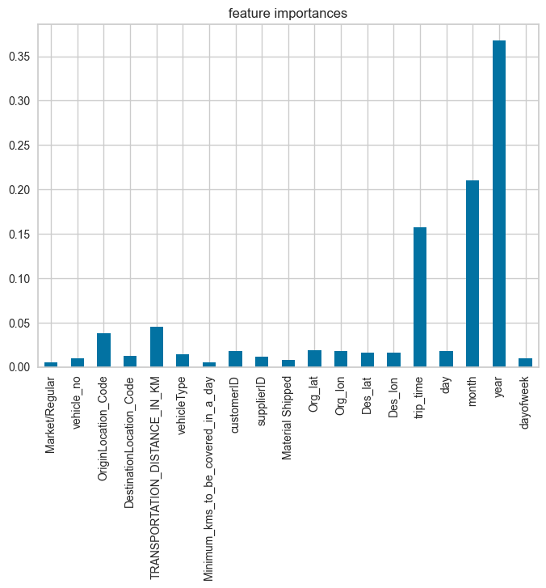

```python
import matplotlib.pyplot as plt

feature_importances = pd.Series(XGB.feature_importances_, index = X.columns)

feature_importances_plot = feature_importances.plot(kind='bar', title='feature importances')
fig = feature_importances_plot.get_figure()
plt.show()
```

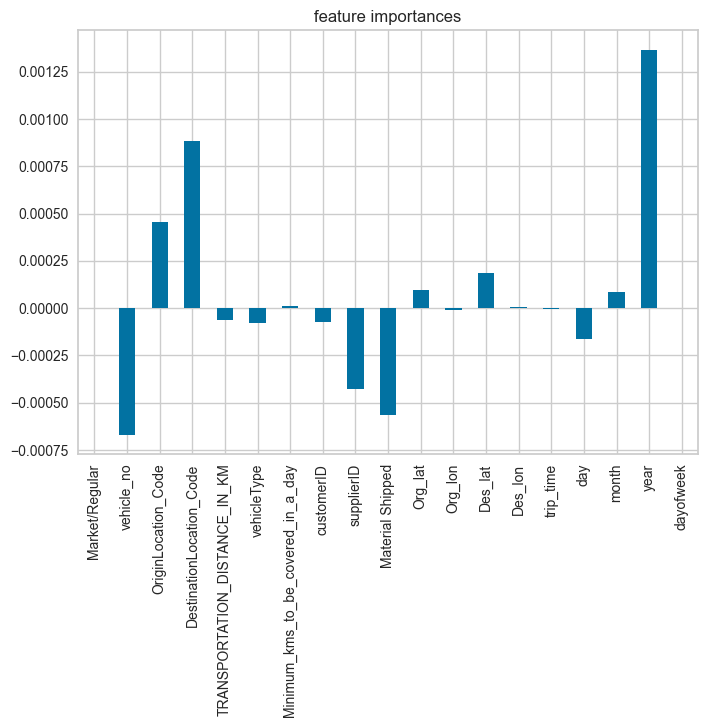

```python
feature_importances = pd.Series(LR.coef_[0], index = X.columns)

feature_importances_plot = feature_importances.plot(kind='bar', title='feature importances')
fig = feature_importances_plot.get_figure()
plt.show()
```

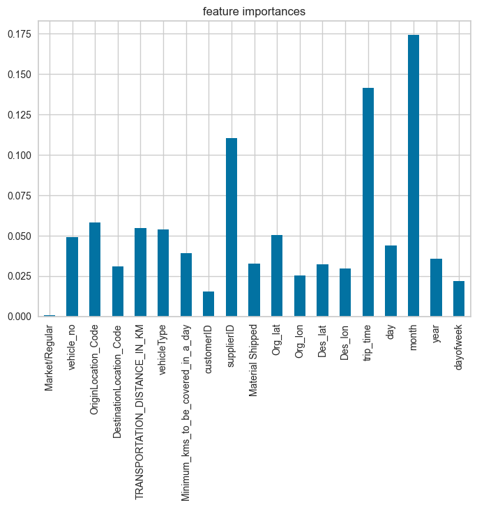

```python
feature_importances = pd.Series(RF.feature_importances_, index = X.columns)

feature_importances_plot = feature_importances.plot(kind='bar', title='feature importances')
fig = feature_importances_plot.get_figure()
plt.show()
```

Important features: • year • month • day

• trip_time • Minimum_kms_to_be_covered_in_a_day • transportation_distance_in_km

• supplierID • Origin_Location_code Note: There can be some correlation between the above 3 features. Suppier information is more important than customer information. Geo locations of customers is important, but identity of them isn't.

• vehicle type • vehicle no.

```python
columns1 = ['OriginLocation_Code', 'vehicle_no', 'TRANSPORTATION_DISTANCE_IN_KM', 'vehicleType', 'Minimum_kms_to_be_covered_in_a_day', 'supplierID', 'trip_time', 'day', 'month', 'year']
```

```python
X1_train = X_train[columns1]
X1_test = X_test[columns1]
```

```
confusion matrix: [[ 710   68]
 [  55 1192]]
accuracy: 0.9392592592592592
precision: 0.946031746031746
recall: 0.9558941459502807
```

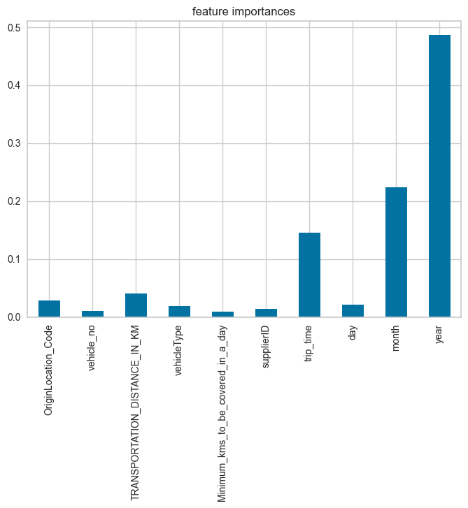

```python
XGB = XGBClassifier()
XGB.fit(X1_train, y_train)
y_predict = XGB.predict(X1_test)

print('confusion matrix:', confusion_matrix(y_test, y_predict))
print('accuracy:', accuracy_score(y_test, y_predict))
print('precision:', precision_score(y_test, y_predict))
print('recall:', recall_score(y_test, y_predict))

feature_importances = pd.Series(XGB.feature_importances_, index = columns1)

feature_importances_plot = feature_importances.plot(kind='bar', title='feature importances')
fig = feature_importances_plot.get_figure()
plt.show()
```

```
confusion matrix: [[ 487  291]
 [ 190 1057]]
accuracy: 0.7624691358024691
precision: 0.7841246290801187
recall: 0.8476343223736968
```

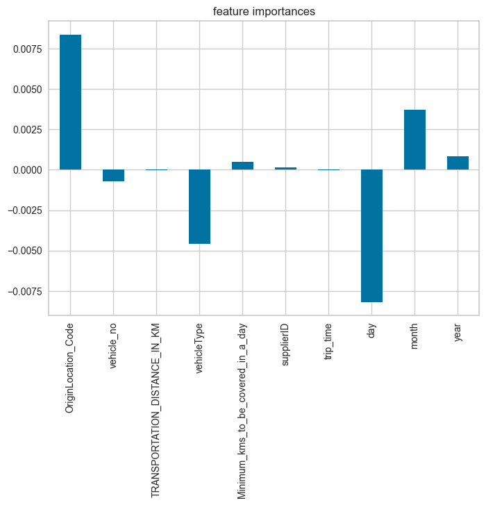

```python
LR = LogisticRegression()
LR.fit(X1_train, y_train)
y_predict = LR.predict(X1_test)

print('confusion matrix:', confusion_matrix(y_test, y_predict))
print('accuracy:', accuracy_score(y_test, y_predict))
print('precision:', precision_score(y_test, y_predict))
print('recall:', recall_score(y_test, y_predict))

feature_importances = pd.Series(LR.coef_[0], index = columns1)

feature_importances_plot = feature_importances.plot(kind='bar', title='feature importances')
fig = feature_importances_plot.get_figure()
plt.show()
```

```
confusion matrix: [[ 715   63]
 [  61 1186]]
accuracy: 0.9387654320987654
precision: 0.9495596477181746
recall: 0.9510825982357658
```

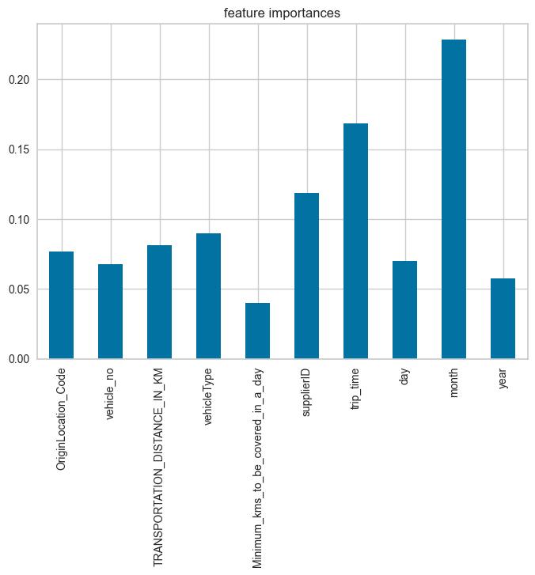

```python
RF = RandomForestClassifier()
RF.fit(X1_train, y_train)
y_predict = RF.predict(X1_test)

print('confusion matrix:', confusion_matrix(y_test, y_predict))
print('accuracy:', accuracy_score(y_test, y_predict))
print('precision:', precision_score(y_test, y_predict))
print('recall:', recall_score(y_test, y_predict))

feature_importances = pd.Series(RF.feature_importances_, index = columns1)

feature_importances_plot = feature_importances.plot(kind='bar', title='feature importances')
fig = feature_importances_plot.get_figure()
plt.show()
```

The performance doesn't suffer much from less features, which supports the selection of features.

# Unsupervised methods

### Preprocess the dataset for clustering algorithms.

Using only selected features Transform the features to follow a normal distribution

```python
X = X[columns1]

from sklearn.preprocessing import QuantileTransformer

qt = QuantileTransformer(output_distribution='normal')
X = qt.fit_transform(X)
```

[output not shown]

### Visualization of clustering after PCA

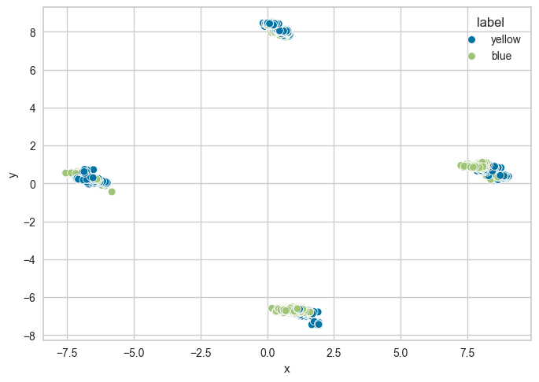

```python
from sklearn.decomposition import  PCA

pca = PCA(n_components=2)
pct = pca.fit_transform(X)

pct = np.delete(pct, 6745, 0)
y_new = np.delete(y.to_numpy(), 6745, 0)

y_new = ['yellow' if elem else 'blue' for elem in y_new]

data = pd.concat([pd.DataFrame(pct), pd.DataFrame(y_new)], axis=1)

data.columns = ['x', 'y', 'label']
import seaborn as sns

sns.scatterplot(data=data, x="x", y="y", hue="label")
```

### KMeans

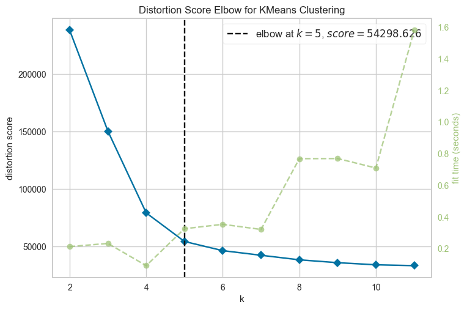

```python
from sklearn.cluster import KMeans
from yellowbrick.cluster import KElbowVisualizer

# Instantiate the clustering model and visualizer
model = KMeans()
visualizer = KElbowVisualizer(model, k=(2, 12))

visualizer.fit(X)        # Fit the data to the visualizer
visualizer.show()
```

The optimal number of clusters is 5.

```python
k_means = KMeans(init="k-means++", n_clusters=2, n_init=10)
k_means.fit(X)

from sklearn.metrics.pairwise import pairwise_distances_argmin

k_means_cluster_centers = k_means.cluster_centers_

k_means_labels = pairwise_distances_argmin(X, k_means_cluster_centers)

from sklearn.metrics.pairwise import pairwise_distances_argmin_min

k_means_distances_df = pd.DataFrame(pairwise_distances_argmin_min(X, k_means_cluster_centers)).T
k_means_distances_df.columns = ['cluster', 'distance']

k_means_distances_df = pd.concat([k_means_distances_df, y], axis=1)
print(k_means_distances_df.groupby(['cluster', 'ontime']).mean())
print(k_means_distances_df.groupby(['cluster', 'ontime']).count())
```

[output not shown]

### Affinity Propagation

```python
from scipy.spatial.distance import pdist

max(pdist(X))
```

```
20.42307758680376
```

```python
from sklearn.cluster import AffinityPropagation

pca = PCA(n_components=3)
pct = pca.fit_transform(X)
af = AffinityPropagation(random_state=0).fit(pct)
cluster_centers_indices = af.cluster_centers_indices_
labels = af.labels_
len(cluster_centers_indices)
```

```
1704
```

I tried different values of preferences based on longest distance between points and PCA Affinity propagation doesn't work

### Mean Shift

```python
from sklearn.cluster import MeanShift, estimate_bandwidth

bandwidth = estimate_bandwidth(X, quantile=0.3)

ms = MeanShift(bandwidth=bandwidth, bin_seeding=True)
ms.fit(X)
labels = ms.labels_
cluster_centers = ms.cluster_centers_
```

```python
mean_shift_distances_df = pd.DataFrame(pairwise_distances_argmin_min(X, cluster_centers)).T
mean_shift_distances_df.columns = ['cluster', 'distance']
mean_shift_distances_df = pd.concat([mean_shift_distances_df, y], axis=1)
mean_shift_distances_df.groupby(['cluster', 'ontime']).mean()
```

| cluster | ontime | distance |
| --- | --- | --- |
| 0.0 | False | 4.031270 |
|  | True | 2.812542 |
| 1.0 | False | 4.629075 |
|  | True | 2.768444 |
| 2.0 | False | 3.024702 |
|  | True | 2.869519 |
| 3.0 | False | 3.615190 |
|  | True | 3.037878 |

```python
mean_shift_distances_df.groupby(['cluster', 'ontime']).count()
```

| cluster | ontime | distance |
| --- | --- | --- |
| 0.0 | False | 1300 |
|  | True | 1452 |
| 1.0 | False | 219 |
|  | True | 1789 |
| 2.0 | False | 819 |
|  | True | 420 |
| 3.0 | False | 182 |
|  | True | 569 |

### Spectral clustering

```python
from sklearn.cluster import SpectralClustering

clustering = SpectralClustering(n_clusters=4, assign_labels='discretize', random_state=0).fit(X)
spectral_clustering = clustering
```

```python
import joblib

joblib.dump(spectral_clustering, 'spectral_clustering_model.pkl')
```

```
['spectral_clustering_model.pkl']
```

```python
loaded_model = joblib.load('spectral_clustering_model.pkl')
```

```python
pd.DataFrame(loaded_model.labels_).value_counts()
```

```
0    6425
2     192
3      79
1      54
Name: count, dtype: int64
```

```python
spectral_clustering_labels_df = pd.DataFrame(spectral_clustering.labels_, columns=['cluster'])
spectral_clustering_labels_df = pd.concat([spectral_clustering_labels_df, y], axis=1)
spectral_clustering_labels_df
```

|  | cluster | ontime |
| --- | --- | --- |
| 0 | 0 | True |
| 1 | 0 | False |
| 2 | 0 | False |
| 3 | 0 | False |
| 4 | 0 | False |
| ... | ... | ... |
| 6745 | 0 | False |
| 6746 | 2 | False |
| 6747 | 0 | False |
| 6748 | 0 | True |
| 6749 | 0 | False |

6750 rows × 2 columns

```python
spectral_clustering_labels_df['cluster'].value_counts()
```

```
cluster
0    6425
2     192
3      79
1      54
Name: count, dtype: int64
```

```python
spectral_clustering_labels_df.value_counts()
```

```
cluster  ontime
0        True      4020
         False     2405
2        True       117
         False       75
3        True        69
1        False       30
         True        24
3        False       10
Name: count, dtype: int64
```

```python
spectral_df.value_counts()
```

[output not shown]

### Hierarchical clustering

```python
from sklearn.cluster import AgglomerativeClustering

hierarchical_clustering = AgglomerativeClustering(n_clusters=5).fit(X)
```

```python
hierarchical_clustering_labels_df = pd.DataFrame(hierarchical_clustering.labels_, columns=['cluster'])
hierarchical_clustering_labels_df = pd.concat([hierarchical_clustering_labels_df, y], axis=1)
pd.DataFrame(hierarchical_clustering_labels_df.value_counts())
```

[output not shown]

### HDBSCAN

```python
from sklearn.cluster import HDBSCAN

hdb = HDBSCAN(min_cluster_size=20)
hdb.fit(X)
```

```
HDBSCAN(min_cluster_size=20)
```

```python
hdbscan_labels_df = pd.DataFrame(hdb.labels_, columns=['clusters'])
hdbscan_labels_df = pd.concat([hdbscan_labels_df, y], axis=1)
hdbscan_labels_df[hdbscan_labels_df.clusters==-1].value_counts()
```

```
clusters  ontime
-1        False     473
          True      439
Name: count, dtype: int64
```

HDBSCAN doesn't work well.

### OPTICS

```python
from sklearn.cluster import OPTICS

optics = OPTICS(min_samples=2).fit(X)
```

```python
optics_labels_df = pd.DataFrame(optics.labels_, columns=['clusters'])
optics_labels_df = pd.concat([optics_labels_df, y], axis=1)
optics_labels_df[optics_labels_df.clusters==-1].value_counts()
```

```
clusters  ontime
-1        True      826
          False     516
Name: count, dtype: int64
```

OPTICS also doesn't work well.

### BIRCH

```python
from sklearn.cluster import Birch

brc = Birch(n_clusters=5)
brc.fit(X)
brc.predict(X)
```

```
array([4, 4, 4, ..., 2, 2, 2])
```

```python
brc_labels_df = pd.DataFrame(brc.labels_, columns=['clusters'])
brc_labels_df = pd.concat([brc_labels_df, y], axis=1)
brc_labels_df.value_counts()
```

```
clusters  ontime
0         True      1789
3         True      1424
2         False      819
4         False      800
1         True       569
3         False      500
2         True       420
0         False      219
1         False      182
4         True        28
Name: count, dtype: int64
```

In clusters 0, 1 and 3, most are anomalies. In cluster 2 and 4, most are not anomalies.